# SWC Tidyverse Workshop: Final assignment

April 4, 2017

## Final assignment

Welcome to the final part of your first step on the journey to become a proficient R user! We hope you enjoyed the learning so far and now we have a challenge for you. We hope you still have the `gapminder_plus` dataset loaded. In case you restarted your R session, here’s a quick line to reload it from disk.

```r
library(tidyverse)
gapminder_plus <- read_csv("./data/gapminder_plus.csv")
```

## Final plot

We will try to reproduce the following plot:

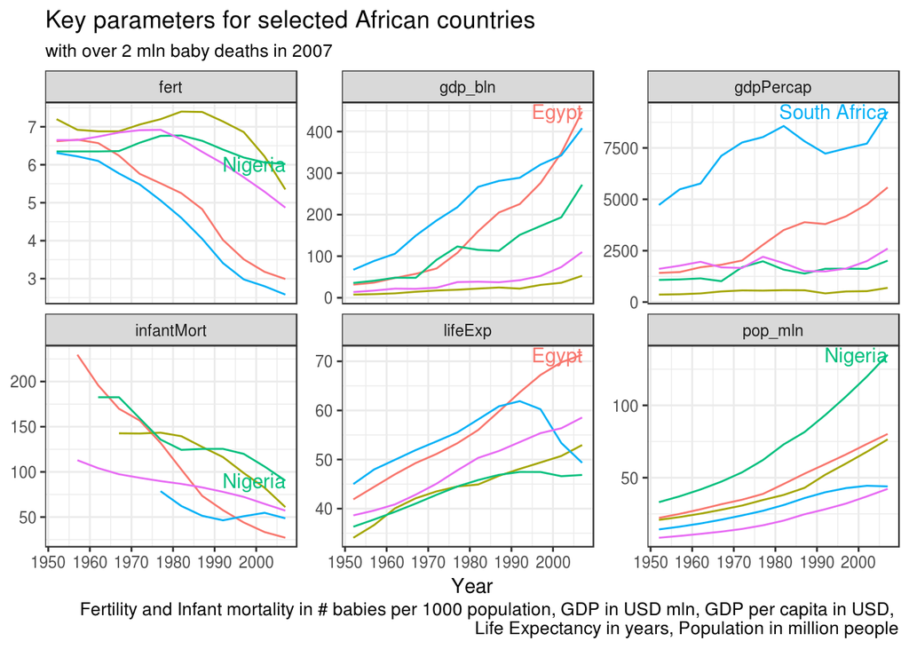

## Preparing the data

First of all, lets look at the chart and assess what data we might need to plot it. The chart says dataset includes selected (few) African countries with at least 2 mln baby deaths in 2007. Let’s see if we can identify those cases

> Remember that our dataset contains `infantMort` and `pop`. Infant mortality is denominated in deaths per 1000 population. Scientific notation of `2e6` is the same as `2*10^6` or 2 mln.

```r
gapminder_plus %>% filter(continent=="Africa", year==2007, infantMort/1000*pop>2e6) %>%
  select(country)
```

```
## # A tibble: 5 × 1
##        country
##          <chr>
## 1        Egypt
## 2     Ethiopia
## 3      Nigeria
## 4 South Africa
## 5        Sudan
```

Now, we need to limit our dataset to include only these countries. What two methods of accomplishing this can you think of? If the number of countries is small (only 5 in this case), we could just list the countries we are interested in in the filter() function. However, as the list increases it will become more difficult to get it typed without errors. Instead, we suggest to use the `_join()` to subset the data.

```r
gapminder_plus %>% filter(continent=="Africa", year==2007, infantMort/1000*pop/10^6>2) %>%
  select(country) %>%
  left_join(gapminder_plus)
```

```
## # A tibble: 60 × 8
##    country  year      pop continent lifeExp gdpPercap  fert infantMort
##      <chr> <int>    <dbl>     <chr>   <dbl>     <dbl> <dbl>      <dbl>
## 1    Egypt  1952 22223309    Africa  41.893  1418.822  6.62         NA
## 2    Egypt  1957 25009741    Africa  44.444  1458.915  6.66      229.7
## 3    Egypt  1962 28173309    Africa  46.992  1693.336  6.57      195.9
## 4    Egypt  1967 31681188    Africa  49.293  1814.881  6.24      169.9
## 5    Egypt  1972 34807417    Africa  51.137  2024.008  5.76      156.8
## 6    Egypt  1977 38783863    Africa  53.319  2785.494  5.51      132.1
## 7    Egypt  1982 45681811    Africa  56.006  3503.730  5.25      102.6
## 8    Egypt  1987 52799062    Africa  59.797  3885.461  4.83       73.5
## 9    Egypt  1992 59402198    Africa  63.674  3794.755  4.02       57.6
## 10   Egypt  1997 66134291    Africa  67.217  4173.182  3.51       44.0
## # ... with 50 more rows
```

Note that on the chart facetting is done not by values of one variable, but by variable itself (i.e. it looks like as though there’s a column that indicates the variable name and facet_wrap is using it to split the data). Does this look familiar? Yeah! Of course, the “long” data looks exactly like that. Let’s see if we can `gather` our dataset into the form which would make it possible to produce this plot.

What variables would we like to keep (not gather)? Well, it seems like we will still need Years (to be used as input to x axis) and we will need countries (to make several lines). Lets exclude those from gathering.

```r
gapminder_plus %>% filter(continent=="Africa", year==2007, infantMort/1000*pop/10^6>2) %>%
  select(country) %>%
  left_join(gapminder_plus) %>%
  gather(key=att, value=val, -c(year,country))
```

```
## # A tibble: 360 × 4
##    country  year   att      val
##      <chr> <int> <chr>    <chr>
## 1    Egypt  1952   pop 22223309
## 2    Egypt  1957   pop 25009741
## 3    Egypt  1962   pop 28173309
## 4    Egypt  1967   pop 31681188
## 5    Egypt  1972   pop 34807417
## 6    Egypt  1977   pop 38783863
## 7    Egypt  1982   pop 45681811
## 8    Egypt  1987   pop 52799062
## 9    Egypt  1992   pop 59402198
## 10   Egypt  1997   pop 66134291
## # ... with 350 more rows
```

Awesome! Lets see how this would look on a plot

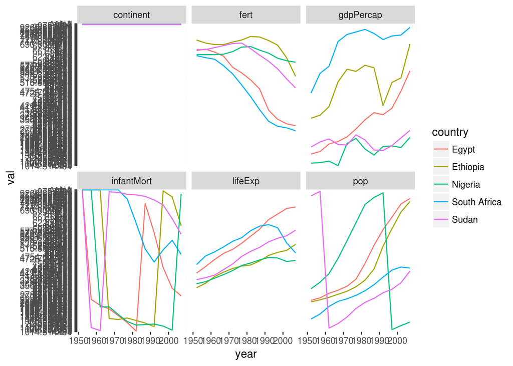

```r
gapminder_plus %>% filter(continent=="Africa", year==2007, infantMort/1000*pop/10^6>2) %>%
  select(country) %>%
  left_join(gapminder_plus) %>%
  gather(key=att, value=val, -c(year,country)) %>%
  ggplot()+
  geom_line(mapping = aes(x=year, y=val, group=country, color=country))+
  facet_wrap(~att)
```

OK, this is messy, but kind of getting us closer to where we want to be. Note that we are plotting different variables on the same plot, so it is very difficult to find a common scale that would fit every variable. Investigate parameters inside the function `facet_wrap` how to add own scale to each facet.

Note that `pop_mln` and `gdp_bln` are two new variables. Also `continent` and `pop` are missing. Lets mutate our data to accommodate those:

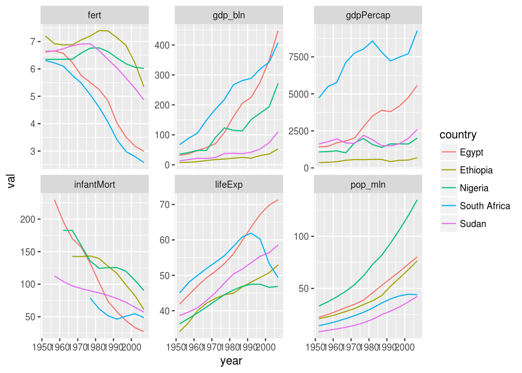

```r
gapminder_plus %>% filter(continent=="Africa", year==2007, infantMort/1000*pop/10^6>2) %>%
  select(country) %>%
  left_join(gapminder_plus) %>%
  mutate(pop_mln=pop/1e6, gdp_bln=gdpPercap*pop/1e9) %>% select(-c(pop,continent)) %>%
  gather(key=att, value=val, -c(year,country)) %>%
  ggplot()+
  geom_line(mapping = aes(x=year, y=val, group=country, color=country))+
  facet_wrap(~att, scales = "free_y")
```

Much better. Notice that overall look and feel of the original chart is different. Experiment with `theme_` functions to identify which of the pre-defined theme might have been used. Also, legend does not seem to appear on the chart. See which parameter in `theme()` function is responsible for positioning of the legend.

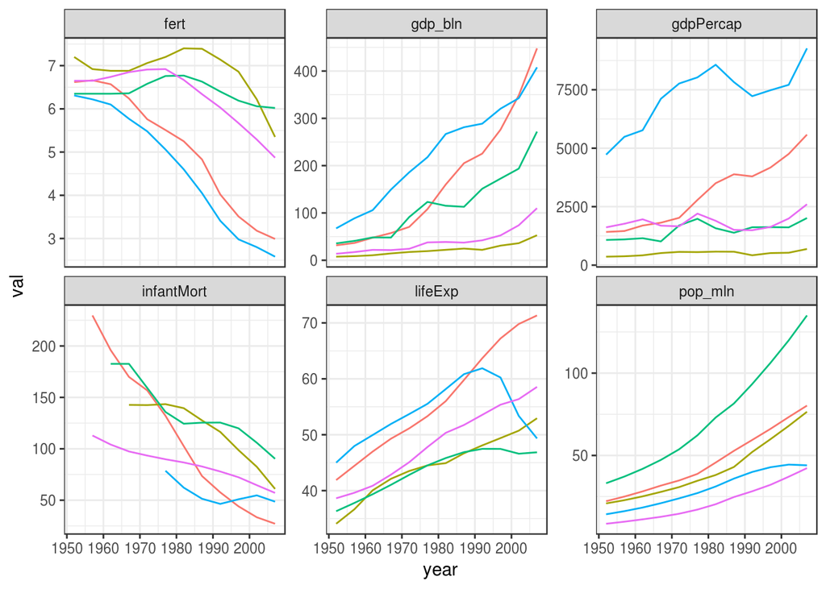

```r
gapminder_plus %>% filter(continent=="Africa", year==2007, infantMort/1000*pop/10^6>2) %>%
  select(country) %>%
  left_join(gapminder_plus) %>%
  mutate(pop_mln=pop/1e6, gdp_bln=gdpPercap*pop/1e9) %>% select(-c(pop,continent)) %>%
  gather(key=att, value=val, -c(year,country)) %>%
  ggplot()+
  geom_line(mapping = aes(x=year, y=val, group=country, color=country))+
  facet_wrap(~att, scales = "free_y")+
  theme_bw()+ theme(legend.position = "none")
```

## Annotating your chart

There are multiple ways to annotate the chart, including manual annotation, but sometimes you can get away with automatic labeling which is quite intuitive and useful. Look closely at the labels (country names) on the chart. what do you notice?

- Only last data point is labeled
- Only highest value in the last year is labeled
- Coloring is the same as the country to which the annotated data point belongs

Now, if you were to take the data that we have and only plot those annotated datapoints, how would you want to proceed with the data wrangling pipe?

```r
gapminder_plus %>% filter(continent=="Africa", year==2007, infantMort/1000*pop/10^6>2) %>%
  select(country) %>%
  left_join(gapminder_plus) %>%
  mutate(pop_mln=pop/1e6, gdp_bln=gdpPercap*pop/1e9) %>% select(-c(pop,continent)) %>%
  gather(key=att, value=val, -c(year,country)) %>%

  filter(year==2007) %>% group_by(att) %>% mutate(max_val=max(val)) %>% filter(val==max_val)
```

```
## Source: local data frame [6 x 5]
## Groups: att [6]
##
##        country  year        att       val   max_val
##          <chr> <int>      <chr>     <dbl>     <dbl>
## 1        Egypt  2007    lifeExp   71.3380   71.3380
## 2 South Africa  2007  gdpPercap 9269.6578 9269.6578
## 3      Nigeria  2007       fert    6.0200    6.0200
## 4      Nigeria  2007 infantMort   90.3000   90.3000
## 5      Nigeria  2007    pop_mln  135.0312  135.0312
## 6        Egypt  2007    gdp_bln  447.9709  447.9709
```

Now, we would like one of the layers (`geom_text`) to use this small dataset of only 6 records, while the rest of the layers should use the complete dataset. Turns out you can accommodate it by specifying own `data` parameter in a layer and utilizing a `dplyr` dot placeholder as a starting point for refining the dataset for the purpose of one layer.

Here’s how you would do it

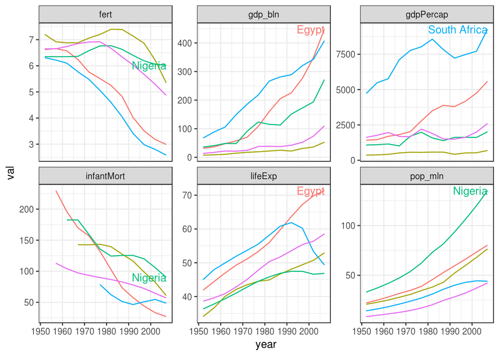

```r
gapminder_plus %>% filter(continent=="Africa", year==2007, infantMort/1000*pop/10^6>2) %>%
  select(country) %>%
  left_join(gapminder_plus) %>%
  mutate(pop_mln=pop/1e6, gdp_bln=gdpPercap*pop/1e9) %>% select(-c(pop,continent)) %>%
  gather(key=att, value=val, -c(year,country)) %>%
  ggplot()+
  geom_line(mapping = aes(x=year, y=val, group=country, color=country))+
  geom_text(data=. %>% filter(year==2007) %>% group_by(att) %>% mutate(max_val=max(val)) %>% filter(val==max_val),
            mapping = aes(x=year, y=max_val, label=country, color=country), hjust="right")+
  facet_wrap(~att, scales = "free_y")+
  theme_bw()+ theme(legend.position = "none")
```

Perfect, lets add descriptions

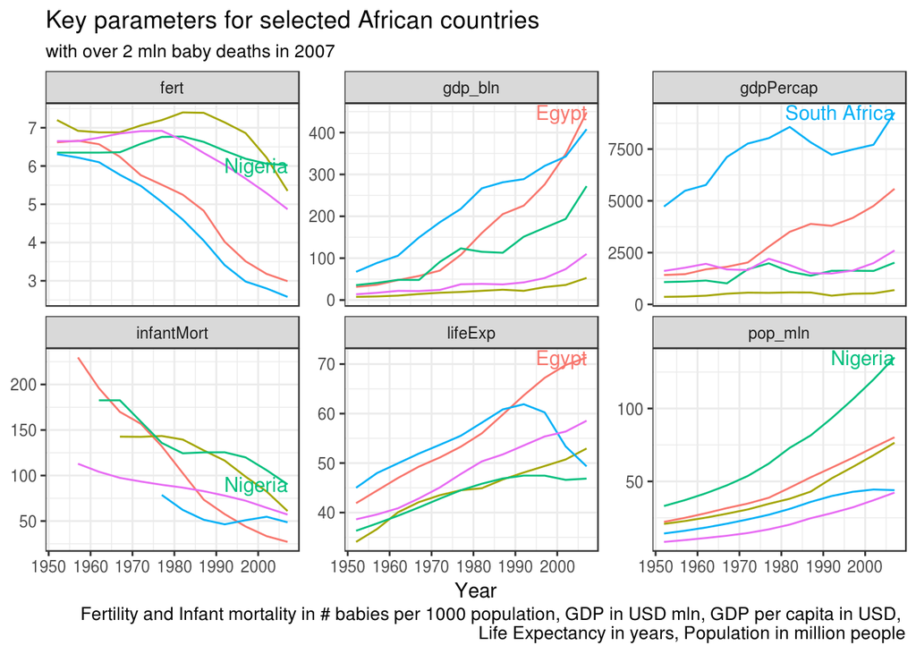

```r
gapminder_plus %>% filter(continent=="Africa", year==2007, infantMort/1000*pop/10^6>2) %>%
  select(country) %>%
  left_join(gapminder_plus) %>%
  mutate(pop_mln=pop/1e6, gdp_bln=gdpPercap*pop/1e9) %>% select(-c(pop,continent)) %>%
  gather(key=att, value=val, -c(year,country)) %>%
  ggplot()+
  geom_line(mapping = aes(x=year, y=val, group=country, color=country))+
  geom_text(data=. %>% filter(year==2007) %>% group_by(att) %>% mutate(max_val=max(val)) %>% filter(val==max_val),
            mapping = aes(x=year, y=max_val, label=country, color=country), hjust="right")+
  facet_wrap(~att, scales = "free_y")+
  theme_bw()+ theme(legend.position = "none") +
labs(title="Key parameters for selected African countries",
       subtitle="with over 2 mln baby deaths in 2007",
       caption="Fertility and Infant mortality in # babies per 1000 population, GDP in USD mln, GDP per capita in USD,
       Life Expectancy in years, Population in million people",
       x="Year", y=NULL)
```